# Progetto SAD

Consiglio Luigi & D’Antuono Francesco Paolo

2024-11-03

# Introduzione

## Descrizione del dataset

Il **PhiUSIIL Phishing URL Dataset** è un dataset progettato per lo studio e l’analisi dei siti di phishing. Contiene **23.580 URL** descritti attraverso **56 variabili** che esplorano proprietà tecniche, strutturali e di sicurezza. Ogni URL è accompagnato da una classificazione come **legittimo (1)** o **phishing (0)**.

Le variabili coprono una vasta gamma di caratteristiche, tra cui:

- **Proprietà dell’URL**: lunghezza dell’URL, numero di sottodomini, presenza di caratteri speciali, e frequenza con cui un determinato TLD (Top-Level Domain, come `.com`) è associato a URL legittimi o di phishing, indicando la probabilità che un TLD specifico sia più o meno affidabile.
- **Caratteristiche testuali**: numero di lettere, numeri e caratteri speciali.
- **Dettagli sul dominio**: lunghezza e struttura del dominio.
- **Elementi strutturali della pagina**: righe di codice, lunghezza della riga più grande, numero di immagini, CSS, JavaScript, reindirizzamenti e popup. Il dataset è particolarmente utile per l’addestramento di modelli di machine learning per la rilevazione del phishing e per analisi statistiche mirate a comprendere i pattern e i fattori di rischio degli URL di phishing.

## Obiettivi del Progetto

1. **Quali caratteristiche degli URL sono maggiormente associate alla probabilità che un sito sia phishing?**
   - Variabili analizzate:
     - `URLLength` (lunghezza dell’URL).
     - `NoOfSubDomain` (numero di sottodomini).
     - `NoOfOtherSpecialCharsInURL` (numero di caratteri speciali nell’URL).

     Tutte e tre le variabili analizzate sono di tipo discreto ovvero possono assumere solo un insieme finito di valori distinti.
2. **È possibile utilizzare i dati generati dai modelli linguistici di grandi dimensioni (LLM) per migliorare la qualità di dataset reali?** I modelli linguistici di grandi dimensioni, possono essere utilizzati per generare dati sintetici basati su pattern appresi da dataset reali. Questa domanda mira a esplorare se tali dati sintetici possano:
   - Arricchire i dataset esistenti, ad esempio simulando URL legittimi o di phishing realistici.

# Caricamento del dataset

La prima fase del progetto richiede il caricamento del dataset all’interno dell’ambiente di sviluppo. Dunque, dopo aver settato il workspace, bisogna andarsi a leggere, dalla cartella di lavoro attuale, il dataset che verrà poi analizzato.

```r
library(tidyverse)
library(dplyr)
library(stats)
dataset <- read.csv("Phishing_URL_Dataset_8.csv", sep = ";", header = TRUE)
```

# Pulizia del dataset

In questa fase, si andrà ad effettuare la pulizia dei dati in modo tale da averli pronti per le successive fasi di analisi del dataset. Vediamo innanzitutto la struttura del dataset.

```r
str(dataset)
```

```
## 'data.frame':    23580 obs. of  56 variables:
##  $ FILENAME                  : chr  "441705.txt" "8023984.txt" "op431.txt" "622028.txt" ...
##  $ URL                       : chr  "https://www.sttiggywinkles.org.uk" "http://9837687563--082935.repl.co" "http://protocolactivac.hostfree.pw/" "https://www.harrisonkitchens.com.au" ...
##  $ URLLength                 : int  32 32 35 34 45 21 21 20 41 28 ...
##  $ Domain                    : chr  "www.sttiggywinkles.org.uk" "9837687563--082935.repl.co" "protocolactivac.hostfree.pw" "www.harrisonkitchens.com.au" ...
##  $ DomainLength              : int  25 26 27 27 36 14 14 13 32 21 ...
##  $ IsDomainIP                : int  0 0 0 0 0 0 0 0 0 0 ...
##  $ TLD                       : chr  "uk" "co" "pw" "au" ...
##  $ URLSimilarityIndex        : num  100 23 45.8 100 51.6 ...
##  $ CharContinuationRate      : num  0.833 0.696 0.667 0.85 0.656 ...
##  $ TLDLegitimateProb         : num  0.028555 0.005977 0.000167 0.010086 0.522907 ...
##  $ URLCharProb               : num  0.0477 0.0146 0.0613 0.063 0.0493 ...
##  $ TLDLength                 : int  2 2 2 2 3 3 3 3 3 2 ...
##  $ NoOfSubDomain             : int  2 1 1 2 1 1 1 1 1 2 ...
##  $ HasObfuscation            : int  0 0 0 0 0 0 0 0 0 0 ...
```

[output cut: 42 more lines]

Come si può notare dai risultati, i tipi dei dati corrispondono alla loro rappresentazione. Ora passiamo a verificare la presenza di righe con valori mancanti.

```r
colSums(is.na(dataset))
```

```
##                   FILENAME                        URL
##                          0                          0
##                  URLLength                     Domain
##                          0                          0
##               DomainLength                 IsDomainIP
##                          0                          0
##                        TLD         URLSimilarityIndex
##                          0                          0
##       CharContinuationRate          TLDLegitimateProb
##                          0                          0
##                URLCharProb                  TLDLength
##                          0                          0
##              NoOfSubDomain             HasObfuscation
##                          0                          0
##         NoOfObfuscatedChar           ObfuscationRatio
##                          0                          0
##           NoOfLettersInURL           LetterRatioInURL
##                          0                          0
##            NoOfDegitsInURL            DegitRatioInURL
##                          0                          0
##            NoOfEqualsInURL             NoOfQMarkInURL
##                          0                          0
##         NoOfAmpersandInURL NoOfOtherSpecialCharsInURL
##                          0                          0
##      SpacialCharRatioInURL                    IsHTTPS
##                          0                          0
##                 LineOfCode          LargestLineLength
##                          0                          0
##                   HasTitle                      Title
##                          0                          0
##      DomainTitleMatchScore         URLTitleMatchScore
##                          0                          0
##                 HasFavicon                     Robots
##                          0                          0
##               IsResponsive            NoOfURLRedirect
##                          0                          0
##           NoOfSelfRedirect             HasDescription
##                          0                          0
##                  NoOfPopup                 NoOfiFrame
##                          0                          0
##      HasExternalFormSubmit               HasSocialNet
##                          0                          0
##            HasSubmitButton            HasHiddenFields
##                          0                          0
##           HasPasswordField                       Bank
##                          0                          0
##                        Pay                     Crypto
##                          0                          0
##           HasCopyrightInfo                  NoOfImage
##                          0                          0
##                    NoOfCSS                     NoOfJS
##                          0                          0
##                NoOfSelfRef               NoOfEmptyRef
##                          0                          0
##            NoOfExternalRef                      label
##                          0                          0
```

Anche in questo caso i risultati ci mostrano che non ci sono righe con valori mancanti all’interno del dataset.

## Rimozione feature ridondanti

Abbiamo analizzato nel dettaglio le feature del dataset e si è notato che ci sono alcune feature del dataset che sono ridondanti e che in qualche modo hanno una certa relazione, rappresentando informazioni simili. Dunque, delle 56 variabili che sono presenti nel dataset originale, ne sono rimaste 30, la cui rimozione verrà effettuata di seguito.

```r
dataset <- dataset[, !names(dataset) %in% c("FILENAME", "URL", "URLSimilarityIndex", "CharContinuationRate", "TLDLegitimateProb", "URLCharProb", "NoOfObfuscatedChar", "ObfuscationRatio", "LetterRatioInURL", "DegitRatioInURL", "SpacialCharRatioInURL", "Title", "DomainTitleMatchScore", "HasFavicon", "Robots", "NoOfURLRedirect", "NoOfSelfRedirect", "HasSubmitButton", "HasPasswordField", "HasCopyrightInfo", "NoOfImage", "NoOfCSS", "NoOfJS", "NoOfSelfRef", "NoOfEmptyRef", "NoOfExternalRef")]
```

La scelta delle feature da rimuovere è stata fatta in base anche alle RQ che la nostra analisi dovrà rispondere, dove sono esposte le feature interessate da ogni RQ.

# Analisi dei dati per RQ1

Le feature che metteremo sotto analisi per la RQ1 sono le seguenti:

- `URLLength`: Lunghezza dell’URL;
- `NoOfSubDomain`: I sottodomini sono URL univoci che risiedono sul dominio acquistato, come estensione davanti al dominio normale. Qui viene identficato il numero di caratteri del sottodominio;
- `NoOfOtherSpecialCharsInURL`: Rappresenta il numero di caratteri speciali in un URL. Procediamo con un’analisi esplorativa di queste variabili.

## Analisi di URLLength

### Frequenze assolute per URLLength

Dopo aver applicato le funzioni di calcolo in R, ecco i risultati ottenuti.

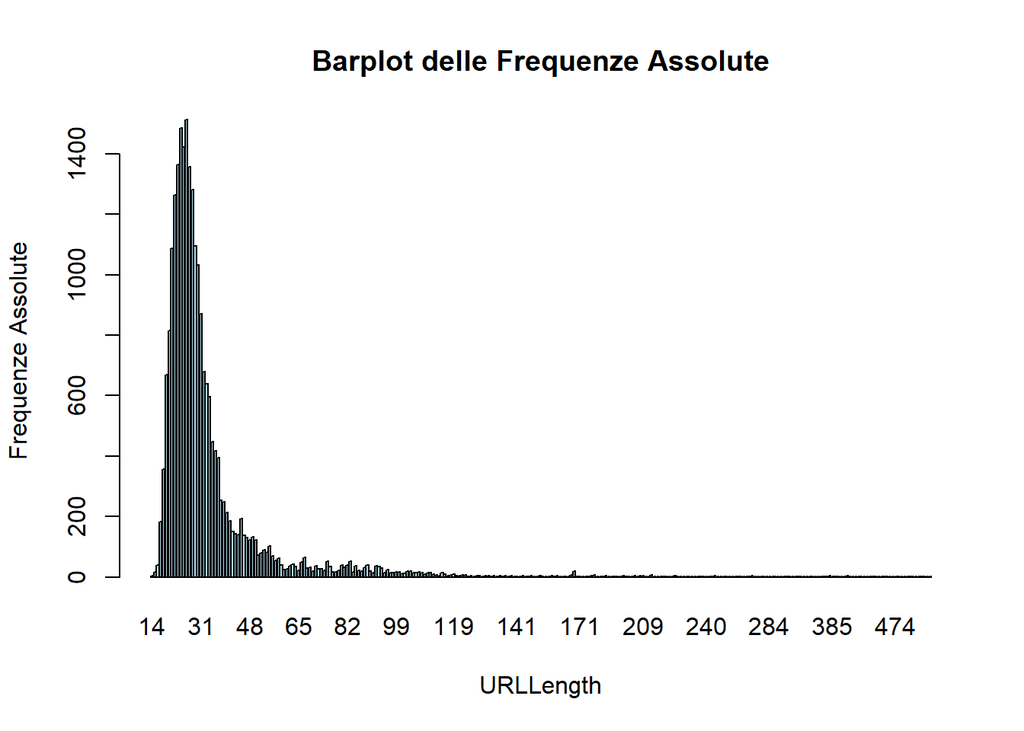

Come si può notare dal grafico, i dati sono molto concentrati nella parte sinistra, ciò ci lascia presupporre che probabilmente ci saranno degli outlier da tenere in considerazione. Successivamente analizzeremo in maniera quantitativa i dati per determinare i valori di questi outlier e dei range più interessanti da prendere in considerazione per le analisi successive.

### Indici di centralità per URLLength

Indici di Centralità per URLLength

|  | Minimo | Massimo | Media | Mediana | Moda |
| --- | --- | --- | --- | --- | --- |
| URLLength | 14 | 1769 | 35.02048 | 28 | 26 |

Come si può notare dagli indici di centralità avremo che la media risulta essere maggiore della mediana, ciò ci indica che la distribuzione dei dati è asimmetrica con una lunga coda a destra (come notato già dalle frequenze). Un’altra informazione importante che si può derivare da questi dati è che il massimo è molto distante dalla centralità dei dati, dunque potrebbe esserci un’influenza importante degli outlier, per quanto riguarda le analisi future.

### Indici di dispersione per URLLength

Anche in questo caso utilizzeremo le funzioni di R per calcolare gli indici di dispersione per la variabile che stiamo analizzando

Indici di Dispersione per URLLength

|  | Range | Varianza | DeviazioneStandard | IQR |
| --- | --- | --- | --- | --- |
| URLLength | 1755 | 1141.889 | 33.79185 | 10 |

Anche questi dati ci mostrano come ci sia una presenza di outlier che influenza molto la distribuzione dei dati che abbiamo a disposizione. Infatti L’IQR e la deviazione standard suggeriscono che la concentrazione dei dati si trova in un range molto piccolo, rispetto al range dei dati che viene esposto. La fase successiva è quella di identificare gli outlier e capire come gestirli.

### Quartili e Box plot per URLLength

Il calcolo dei quartili ci consentirà di capire nel dettaglio la distribuzione dei dati in percentuale.

Quartili per URLLength

|  | Q0 | Q1_25_Percentile | Q2_50_Percentile | Q3_75_Percentile | Q4 |
| --- | --- | --- | --- | --- | --- |
| URLLength | 14 | 24 | 28 | 34 | 1769 |

Questi risultati mostrano come il 75% dei dati che sono presenti all’interno del dataset per la variabile *URLLength* arrivano fino al valore 34, ciò significa che, considerato l’IQR calcolato precedentemente, tutto ciò che è al di fuori del range è considerabile outlier.

Di conseguenza, il boxplot risulterà molto schiacciato e difficilmente visibile ed analizzabile. Dunque bisognerà procedere con una rimozione degli outlier, poiché ci sono dati troppo distanti e poco frequenti, che risultano poco significativi. Vediamolo di seguito.

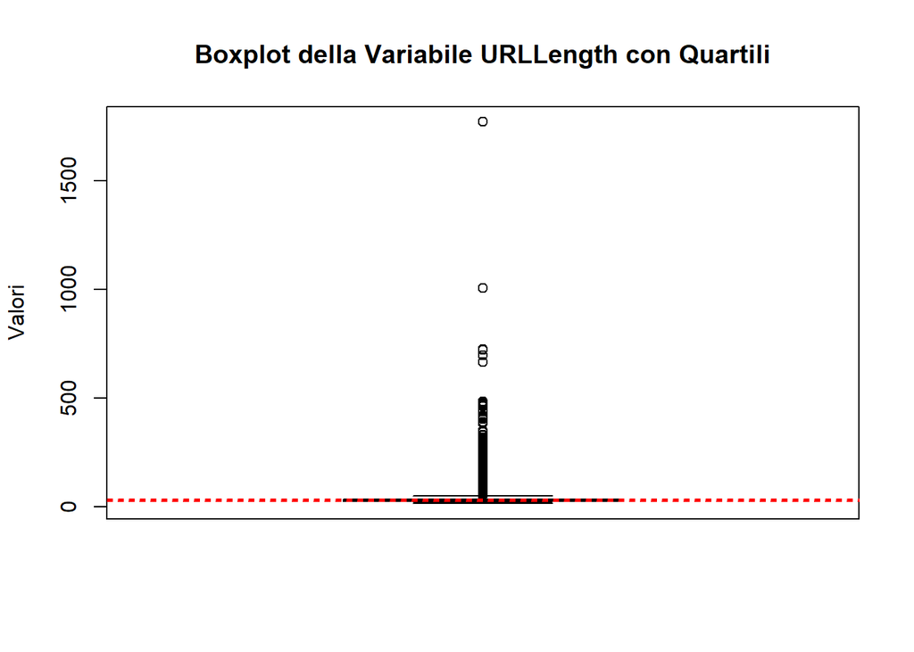

### Rimozione outlier tramite metodo dell’IQR

Abbiamo già calcolato precedente l’IQR, dunque ci basta semplicemente quantificare il limite superiore e inferiore, oltre il quale i nostri dati saranno considerati outlier.

```
## Lower Bound:  9
```

```
## Upper Bound:  49
```

```
## Numero di righe nel dataset filtrato: 21071
```

Dopo la rimozione degli outlier, il dataset conterrà 21071 osservazioni, circa l’11% in meno rispetto all’originale, ora andremo a rianalizzare la variabile confrontandola con i dati originali, per capire se la rimozione degli outlier ha rimasto invariata la distribuzione dei dati. Ciò ci permetterà di capire se i dati rimossi erano significativi o meno.

### Confronto distribuzioni URLLength pre e post-filtraggio

Per confrontare le distribuzioni, andremo a rappresentare degli istogrammi pre e post-filtraggio e compararli per capire l’andamento dei dati.

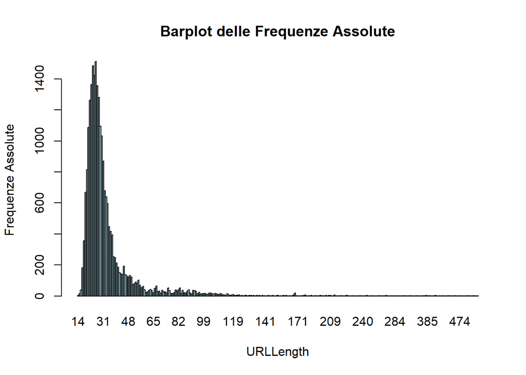

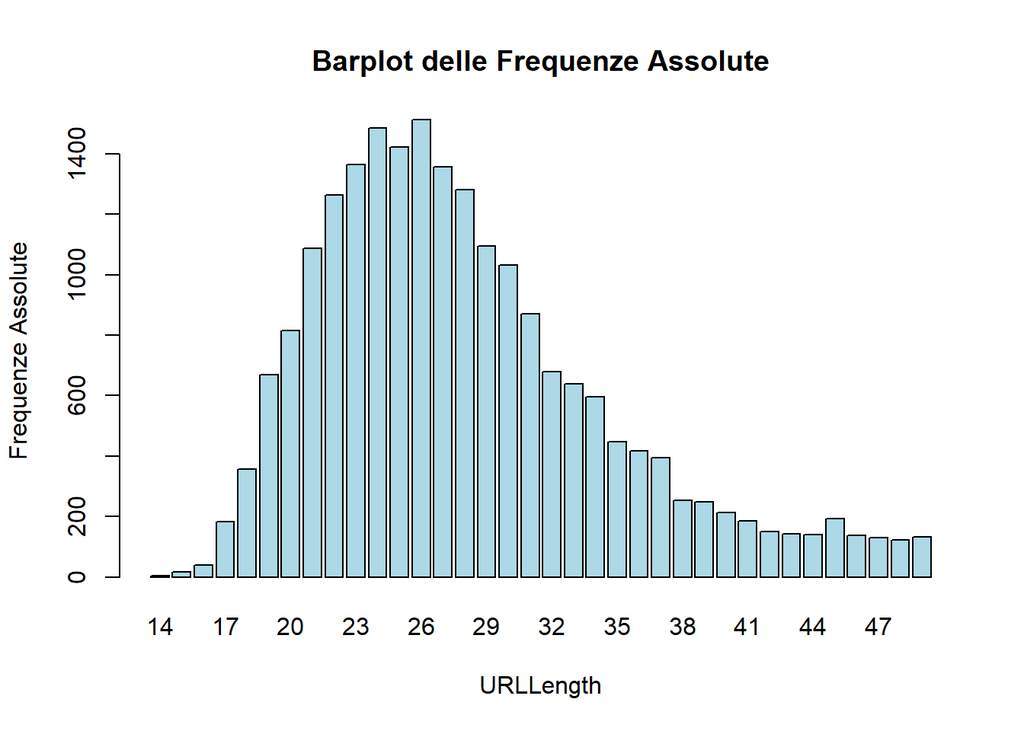

```r
# Percentuale di phishing nel dataset originale
table(dataset$label) / nrow(dataset)
```

```
##
##         0         1
## 0.4305768 0.5694232
```

```r
# Percentuale di phishing nel dataset senza outlier
table(dataset_without_outliers$label) / nrow(dataset_without_outliers)
```

```
##
##         0         1
## 0.3627735 0.6372265
```

```r
outliers <- dataset %>% filter(URLLength > 49)
table(outliers$label) / nrow(outliers)
```

```
##
## 0
## 1
```

```r
#Esporre dati sulla lunghezza dell'URL confrontando la probabilità di phishing e la distribuzione di questi dati da entrambi i dataset
```

## Analisi di NoOfSubDomain

### Frequenze assolute per NoOfSubDomain

Dopo aver applicato le funzioni di calcolo in R, ecco i risultati ottenuti.

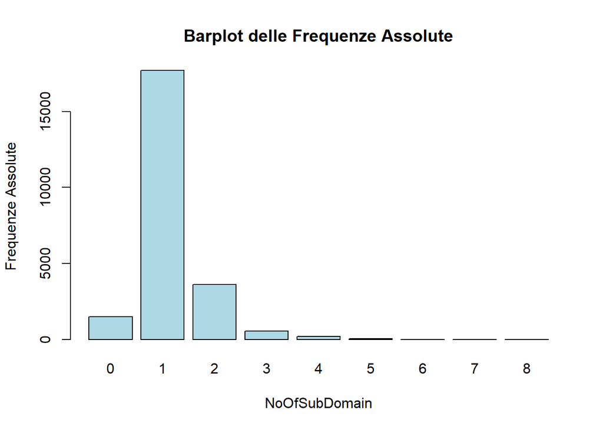

[output not shown]

### Indici di centralità per NoOfSubDomain

Indici di Centralità per NoOfSubDomain

|  | Minimo | Massimo | Media | Mediana | Moda |
| --- | --- | --- | --- | --- | --- |
| NoOfSubDomain | 0 | 8 | 1.168193 | 1 | 1 |

### Indici di dispersione per NoOfSubDomain

Indici di Dispersione per NoOfSubDomain

|  | Range | Varianza | DeviazioneStandard | IQR |
| --- | --- | --- | --- | --- |
| NoOfSubDomain | 8 | 0.3867401 | 0.6218843 | 0 |

Il calcolo dei quartili ci consentirà di capire nel dettaglio la distribuzione dei dati in percentuale.

Quartili per NoOfSubDomain

|  | Q0 | Q1_25_Percentile | Q2_50_Percentile | Q3_75_Percentile | Q4 |
| --- | --- | --- | --- | --- | --- |
| NoOfSubDomain | 0 | 1 | 1 | 1 | 8 |

## Analisi di NoOfOtherSpecialCharsInURL

### Frequenze assolute per NoOfOtherSpecialCharsInURL

Dopo aver applicato le funzioni di calcolo in R, ecco i risultati ottenuti.

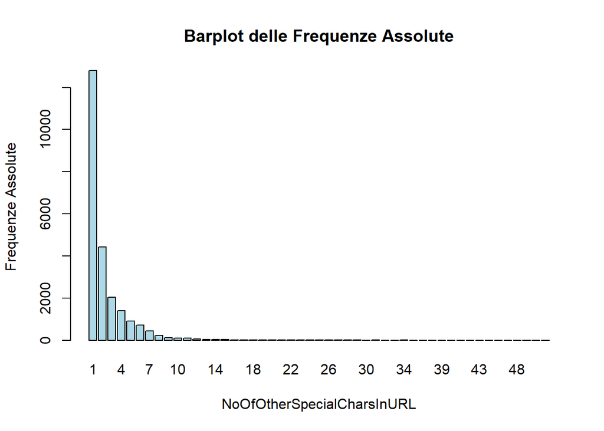

### Indici di centralità per NoOfOtherSpecialCharsInURL

Indici di Centralità per NoOfOtherSpecialCharsInURL

|  | Minimo | Massimo | Media | Mediana | Moda |
| --- | --- | --- | --- | --- | --- |
| NoOfOtherSpecialCharsInURL | 1 | 87 | 2.392918 | 1 | 1 |

### Indici di dispersione per NoOfOtherSpecialCharsInURL

Indici di Dispersione per NoOfOtherSpecialCharsInURL

|  | Range | Varianza | DeviazioneStandard | IQR |
| --- | --- | --- | --- | --- |
| NoOfOtherSpecialCharsInURL | 86 | 8.597422 | 2.932136 | 2 |

Il calcolo dei quartili ci consentirà di capire nel dettaglio la distribuzione dei dati in percentuale.

Quartili per NoOfOtherSpecialCharsInURL

|  | Q0 | Q1_25_Percentile | Q2_50_Percentile | Q3_75_Percentile | Q4 |
| --- | --- | --- | --- | --- | --- |
| NoOfOtherSpecialCharsInURL | 1 | 1 | 1 | 3 | 87 |